# Métodos de Monte Carlo

## Tabla de contenidos

- Métodos de Monte Carlo
  - Introducción
  - Monte Carlo
  - Cadenas de Markov
  - Monte Carlo con Cadenas de Markov
  - !Y hay mucho más!

## Introducción

### [Todo es un maldito promedio (Sosa Escudero)](https://twitter.com/wsosaescudero/status/936704683590250496)

**Caso 1**: Observe la distribución de los ingresos de personas. ¿normal? Ni a palos. Hay muchos pobres y muy poquitos ricos. Mas o menos asi.

[figure not shown]

Experimento mental: agrupemos a la gente en “pueblos” al azar y calculemos el ingreso promedio de cada pueblo. La distribución del ingreso no es normal, pero… ¿Y la del ingreso promedio de los pueblos?

Si, acertaste: normal. Ejemplo: la distribución del ingreso de las personas no es normal, pero la de los ingresos promedio de municipios si lo es.

Que paso? Agrupar limó las puntas, en cada “pueblo” hay ricos y pobres que fueron rejuntados en el promedio. Las comparaciones entre personas no son “gaussianas”, las comparaciones entre pueblos si lo son.

**Caso 2**: dos candidatos. La proporción de votantes a un candidato es un promedio (de 0’s y 1’s: 1 si voto a un candidato, 0 si no). Un promedio, ergo normal.

### El problema del cálculo de valores esperados

Dados

- un espacio de estados $E$
- una distribución de probabilidad $\mu$
- una función $f:E \to \mathbb{R}$

se quiere calcular

$$\mathbb{E}[f] = \int_E f(x)\mu(x)dx$$

Métodos de Monte Carlo hace alusión a un conjunto de métodos basados en generar estados por simulación para quedarse con el promedio de la función evaluada en dichos estados.

- Monte Carlo: cuando sabes simular la distribución $\mu$
- Monte Carlo con Cadenas de Markov: cuando no sabes simular la distribución $\mu$

## Monte Carlo

### Aproximación de $\pi$

La tarea es calcular una aproximación a $\pi$ utilizando [Monte Carlo](https://en.wikipedia.org/wiki/Monte_Carlo_method)

Sugerencias:

- Si $U$ es una variable aleatoria uniforme bivariada en el cuadrado unitario $[0,1]\times [0,1]$, entonces la probabilidad de que $U$ se encuentre en un subconjunto $B$ de $[0,1]\times [0,1]$ es igual al área de $B$.
- Si $U_1,\ldots,U_n$ son copias IID de $U$, entonces, a medida que $n$ crece, la fracción que cae en $B$ converge a la probabilidad de caer en $B$.
- Para un círculo, $area = \pi \cdot radio^2$.

Idea:

- Considere el círculo de diámetro 1 incrustado en el cuadrado unitario.
- Sea $A$ su área y sea $r=1/2$ su radio.
- Si sabemos $\pi$ entonces podemos calcular $A$ a través de $A = \pi r^2$.
- Pero aquí el punto es calcular $\pi$, lo cual podemos hacer por $\pi = A / r^2$.

Resumen: Si podemos estimar el área de un círculo con diámetro 1, entonces dividiendo por $r^2 = (1/2)^2 = 1/4$ da una estimación de $\pi$.

Estimamos el área muestreando uniformes bivariados y observando la fracción que cae dentro del círculo.

```python
import numpy as np
```

```python
def calculate_pi(n=1_000_000):
    count = 0
    for i in range(n):
        u, v = np.random.uniform(0, 1), np.random.uniform(0, 1)
        d = np.sqrt((u - 0.5)**2 + (v - 0.5)**2)
        if d < 0.5:
            count += 1

    area_estimate = count / n
    return area_estimate * 4  # dividing by radius**2
```

```python
np.random.seed(100)
%time a=calculate_pi()
```

```
CPU times: total: 4.31 s
Wall time: 4.31 s
```

```python
np.random.seed(100)
%time b=calculate_pi()
```

```
CPU times: total: 4.34 s
Wall time: 4.38 s
```

```python
print('%.10f' % a)
print('%.10f' % b)
```

```
3.1429360000
3.1429360000
```

## Cadenas de Markov

Las cadenas de Markov son una de las clases más útiles de procesos estocásticos, siendo

- simple, flexible y respaldadas por muchos elegantes resultados teóricos
- valioso para desarrollar la intuición sobre modelos dinámicos aleatorios
- central para el modelado cuantitativo

Los encontrará en muchos de los modelos de caballos de batalla de la economía y las finanzas.

Aquí, revisamos parte de la teoría de las cadenas de Markov y presentaremos algunos programas para trabajar con cadenas de Markov disponibles en [QuantEcon.py](http://quantecon.org/quantecon-py).

Primero instalamos la librería:

- `!pip install quantecon`
- `!pip install --upgrade quantecon`

```python
import quantecon as qe
```

### Simulación con QuantEcon

**Ejemplo: empleado/desempleado**

Considere un trabajador que, en un momento dado $t$, está desempleado (estado 0) o empleado (estado 1).

Supongamos que, durante un período de un mes,

1. Un trabajador desempleado encuentra trabajo con probabilidad $\alpha \in (0, 1)$.
2. Un trabajador ocupado pierde su trabajo y queda desempleado con probabilidad $\beta \in (0, 1)$.

En términos de un modelo de Markov, tenemos

- $E = \{0, 1\}$
- $P(0, 1) = \alpha$ y $P(1, 0) = \beta$

Podemos escribir las probabilidades de transición en forma de matriz como

$$ P = \left( \begin{array}{cc} 1 - \alpha & \alpha \\ \beta & 1 - \beta \end{array} \right) $$

Una vez que tengamos los valores $\alpha$ y $\beta$, podemos abordar una variedad de preguntas, como

- ¿Cuál es la duración media del desempleo?
- A largo plazo, ¿qué fracción de tiempo se encuentra un trabajador desempleado?
- Condicional al empleo, ¿cuál es la probabilidad de quedar desempleado al menos una vez en los próximos 12 meses?

Luego abordaremos estas preguntas.

[QuantEcon.py](http://quantecon.org/quantecon-py) tiene rutinas para manejar cadenas de Markov, incluida la simulación. Por ejemplo:

```python
#from quantecon import MarkovChain

P = [[0.4, 0.6],
     [0.2, 0.8]]
mc = qe.MarkovChain(P)
X = mc.simulate(ts_length=1_000_000)
X[:5]
```

```
array([0, 1, 1, 1, 1])
```

```python
np.mean(X == 0)
```

```
0.249889
```

La librería [QuantEcon.py](http://quantecon.org/quantecon-py) usa [JIT](https://python-programming.quantecon.org/numba.html#numba-link) y es mucho más rápido.

```python
%time mc.simulate(ts_length=1_000_000) # qe version
```

```
CPU times: total: 15.6 ms
Wall time: 16.1 ms
```

```
array([1, 1, 1, ..., 1, 1, 1])
```

Si lo deseamos, podemos proporcionar una especificación de valores de estado a `MarkovChain`.

Estos valores de estado pueden ser enteros, flotantes o incluso cadenas.

```python
mc = qe.MarkovChain(P, state_values=('unemployed', 'employed'))
```

```python
mc.simulate(ts_length=5, init='employed') # init: por defecto usa un estado inicial aleatorio
```

```
array(['employed', 'employed', 'employed', 'employed', 'employed'],
      dtype='<U10')
```

**Ejemplo: ciclo económico**

Usando datos de desempleo de EE. UU., Hamilton (What's real about the business cycle?, 2005) estimó la matriz estocástica

$$ P = \left( \begin{array}{ccc} 0.971 & 0.029 & 0 \\ 0.145 & 0.778 & 0.077 \\ 0 & 0.508 & 0.492 \end{array} \right) $$

dónde

- la frecuencia es mensual
- el primer estado representa "crecimiento normal"
- el segundo estado representa "recesión leve"
- el tercer estado representa "recesión severa"

Por ejemplo, la matriz nos dice que cuando el estado es de crecimiento normal, el estado volverá a ser de crecimiento normal el próximo mes con una probabilidad de 0.97.

Este proceso de Markov también se puede representar como un gráfico dirigido, con bordes etiquetados por probabilidades de transición.

[figure not shown]

Aquí "ng" es un crecimiento normal, "mr" es una recesión leve, "sr" es una recesión severa.

Supongamos que se desconoce el estado actual (quizás las estadísticas estén disponibles solo al *final* del mes actual).

Estimamos que la probabilidad de que la economía esté inicialmente en el estado $x$ sea $\mu(x)$.

La *probabilidad de estar en recesión* (ya sea leve o severa) en 6 meses viene dada por

$$ \mu P^6 \cdot \left( \begin{array}{c} 0 \\ 1 \\ 1 \end{array} \right) $$

```python
P = np.array([[0.971, 0.029, 0],
               [0.145, 0.778, 0.077],
               [0, 0.508, 0.492]])
mu = np.array([[0.9, 0.05, 0.05]])
v = np.array([[0],[1],[1]])
```

```python
(mu @ np.linalg.matrix_power(P,6) ) @ v
```

```
array([[0.15877547]])
```

**Irreducibilidad**

Por ejemplo, considere las siguientes probabilidades de transición para la riqueza de un conjunto ficticio de hogares

[figure not shown]

Podemos traducir esto a una matriz estocástica, poniendo ceros donde no hay arista entre los nodos

$$ P := \left( \begin{array}{ccc} 0.9 & 0.1 & 0 \\ 0.4 & 0.4 & 0.2 \\ 0.1 & 0.1 & 0.8 \end{array} \right) $$

Está claro en el gráfico que esta matriz estocástica es irreducible: podemos llegar a cualquier estado desde cualquier otro estado eventualmente.

También podemos probar esto usando la clase MarkovChain de [QuantEcon.py](http://quantecon.org/quantecon-py)

```python
P = [[0.9, 0.1, 0.0],
     [0.4, 0.4, 0.2],
     [0.1, 0.1, 0.8]]

mc = qe.MarkovChain(P, ('poor', 'middle', 'rich'))
mc.is_irreducible
```

```
True
```

Aquí hay un escenario más pesimista, donde los pobres son pobres siempre.

[figure not shown]

Esta matriz estocástica no es irreductible, ya que, por ejemplo, un pobre no puede hacerse rico.

```python
P = [[1.0, 0.0, 0.0],
     [0.1, 0.8, 0.1],
     [0.0, 0.2, 0.8]]

mc = qe.MarkovChain(P, ('poor', 'middle', 'rich'))
mc.is_irreducible
```

```
False
```

Puede que ya le haya quedado claro que la irreductibilidad va a ser importante en términos de resultados a largo plazo.

Por ejemplo, la pobreza es una cadena perpetua en el segundo gráfico pero no en el primero.

**Aperiodicidad**

Hablando en términos generales, una cadena de Markov se llama *periódica* si retorna de una manera predecible y aperiódica en caso contrario.

Aquí hay un ejemplo trivial con tres estados.

[figure not shown]

La cadena cicla con el período 3:

Más formalmente, el **período** de un estado $x$, $d_x$, es el máximo común divisor del conjunto de enteros

$$ L_x := \{n \geq 1 : P^n(x, x) > 0\} $$

En el último ejemplo, $L_x = \{3, 6, 9, \ldots\}$ para cada estado $x$, por lo que el período es 3.

Una matriz estocástica se llama **aperiódica** si el periodo de cada estado es 1, $d_x=1$; y **periódico** en caso contrario.

Por ejemplo, la matriz estocástica asociada con las probabilidades de transición a continuación es periódica porque, por ejemplo, el estado $a$ tiene un período 2

[figure not shown]

Podemos confirmar que la matriz estocástica es periódica de la siguiente manera

```python
P = [[0.0, 1.0, 0.0, 0.0],
     [0.5, 0.0, 0.5, 0.0],
     [0.0, 0.5, 0.0, 0.5],
     [0.0, 0.0, 1.0, 0.0]]

mc = qe.MarkovChain(P)
mc.period
```

```
2
```

```python
mc.is_aperiodic
```

```
False
```

## Monte Carlo con Cadenas de Markov

### Distribuciones invariantes

Una distribución $\mu$ sobre $E$ se llama **estacionaria** para $P$ si $\mu = \mu P$.

(Esta es la misma noción de estacionariedad para procesos AR(1) aplicados a un entorno diferente).

De esta igualdad, obtenemos inmediatamente $\mu = \mu P^n$ para todo $n$.

Esto nos dice un hecho importante: si la distribución de $X_0$ es una distribución estacionaria, entonces $X_n$ tendrá esta misma distribución para todos los $n$.

**Ejemplo: empleo/desempleo**

Suponiendo $\alpha \in (0,1)$ y $\beta \in (0,1)$, se cumple la condición de ergodicidad uniforme.

Sea $\mu = (p, 1-p)$ la distribución estacionaria, de manera que $p$ corresponde al desempleo (estado 0).

Usando $\mu = \mu P$ y un poco de álgebra se obtiene

$$ p = \frac{\beta}{\alpha + \beta} $$

Esto es, en cierto sentido, una probabilidad de desempleo de estado estacionario; más sobre la interpretación a continuación.

No es sorprendente que tienda a cero cuando $\beta \to 0$, y a uno cuando $\alpha \to 0$.

```python
a=0.6
b=0.2
p=b/(a+b)
P = np.array([[1-a, a],
              [b, 1-b]])
mu = (p, 1-p)
mu @ P
```

```
array([0.25, 0.75])
```

Una matriz de Markov dada $P$ puede tener muchas distribuciones estacionarias. Necesitamos imponer la restricción de que la solución debe ser una distribución de probabilidad.

**Problema del vector propio:** un vector $\mu$ tal que $\mu = \mu P$ es un vector propio asociado con autovalor unitario $\lambda = 1$ tal que ${\|\mu\|}_1=1$.

Un algoritmo estable y sofisticado especializado en matrices estocásticas está implementado en [QuantEcon.py](http://quantecon.org/quantecon-py).

```python
P = [[0.4, 0.6],
     [0.2, 0.8]]

mc = qe.MarkovChain(P)
mc.stationary_distributions  # Show all stationary distributions
```

```
array([[0.25, 0.75]])
```

### Convergencia al Equilibrio

Bajo irreductibilidad, se cumple: para todo $x \in S$,

\begin{equation} \frac{1}{N} \sum_{t = 0}^{N-1} \mathbf{1}\{X_t = x\} \to \mu^*(x) \quad \text{cuando } N \to \infty \end{equation}

Aquí

- $\mathbf{1}\{X_t = x\} = 1$ si $X_t = x$ y cero en caso contrario
- la convergencia es con probabilidad uno
- el resultado no depende de la distribución (o valor) de $X_0$

El resultado nos dice que la fracción de tiempo que la cadena pasa en el estado $x$ converge a $\mu^*(x)$ cuando el tiempo tiende al infinito.

Esto nos brinda otra forma de interpretar la distribución estacionaria, siempre que el resultado de la convergencia sea válido.

El resultado de convergencia es un caso especial de un resultado de ley de números grandes para cadenas de Markov; consulte [EDTC](http://johnstachurski.net/edtc.html), sección 4.3.4 para obtener información adicional.

Este teorema de convergencia para cadenas de Markov nos dice que la distribución de $X_n$ converge a la distribución estacionaria independientemente de dónde empecemos.

Esto agrega un peso considerable a nuestra interpretación de $\mu^*$ como un estado estacionario estocástico.

La convergencia en el teorema se ilustra en la siguiente figura.

```python
%matplotlib inline
import matplotlib.pyplot as plt
from mpl_toolkits.mplot3d import Axes3D
```

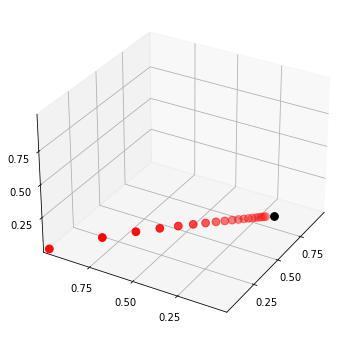

```python
P = ((0.971, 0.029, 0.000),
     (0.145, 0.778, 0.077),
     (0.000, 0.508, 0.492))
P = np.array(P)

mu = (0.0, 1.0, 0.0)        # Initial condition

fig = plt.figure(figsize=(8, 6))
ax = fig.add_subplot(111, projection='3d')

ax.set(xlim=(0, 1), ylim=(0, 1), zlim=(0, 1),
       xticks=(0.25, 0.5, 0.75),
       yticks=(0.25, 0.5, 0.75),
       zticks=(0.25, 0.5, 0.75))

x_vals, y_vals, z_vals = [], [], []
for t in range(20):
    x_vals.append(mu[0])
    y_vals.append(mu[1])
    z_vals.append(mu[2])
    mu = mu @ P

ax.scatter(x_vals, y_vals, z_vals, c='r', s=60)
ax.view_init(30, 210)

mc = qe.MarkovChain(P)
mu_star = mc.stationary_distributions[0]
ax.scatter(mu_star[0], mu_star[1], mu_star[2], c='k', s=60)

plt.show()
```

Aquí

- $P$ es la matriz estocástica de recesión y crecimiento.
- El punto rojo más a la izquierda es una distribución de probabilidad inicial elegida arbitrariamente $\mu=(0,1,0)$, representada como un vector en $\mathbb R^3$.
- Los otros puntos rojos son las distribuciones $\mu P^n$ para $n = 1, 2, \ldots$.
- El punto negro es $\mu^*$.

Es posible que desee intentar experimentar con diferentes condiciones iniciales como $\mu=(0.9,0.05,0.05)$

**Ejemplo: distribuciones transversales**

Recuerde nuestro modelo de dinámica de empleo/desempleo para un trabajador dado.

Considere una gran población de trabajadores, cada uno de cuya experiencia de vida está descrita por la dinámica especificada, independientemente unos de otros.

Sea $\mu$ la distribución *transversal* actual sobre $\{ 0, 1 \}$.

La distribución transversal registra las fracciones de trabajadores ocupados y desocupados en un momento dado.

- Por ejemplo, $\mu(0)$ es la tasa de desempleo.

¿Cuál será la distribución transversal dentro de 10 períodos?

La respuesta es $\mu P^{10}$, donde $P$ es la matriz estocástica.

Esto se debe a que cada trabajador se actualiza de acuerdo con $P$, por lo que $\mu P^{10}$ representa las probabilidades de un solo trabajador seleccionado al azar de la gran población.

Pero cuando la muestra es grande, los resultados y las probabilidades son aproximadamente iguales (según la ley de los grandes números).

Entonces, para una población muy grande (que tiende a infinito), $\mu P^{10}$ también representa la fracción de trabajadores en cada estado dentro de 10 períodos.

Esta es exactamente la *distribución transversal* dentro de 10 períodos.

Ahora, suponga que $\alpha \in (0,1)$ y $\beta \in (0,1)$, de modo que tanto la irreductibilidad como la aperiodicidad se cumplen.

Vimos que la distribución estacionaria es $\mu^*=(p, 1-p)$, donde

$$ p = \frac{\beta}{\alpha + \beta} $$

En la interpretación transversal, esta es la fracción de personas desempleadas en un momento dado.

En vista de nuestro último resultado, también es la fracción de tiempo que un trabajador puede esperar pasar desempleado.

Por lo tanto, a largo plazo, los promedios transversales de una población y los promedios de series temporales de una persona dada coinciden.

Esta es una interpretación de la noción de ergodicidad.

## !Y hay mucho más!

Lo siguiente se basa en el artículo de [Betancourt (2018)](https://arxiv.org/pdf/1701.02434.pdf)

Para el problema del cálculo de esperanzas

$$\mathbb{E}[f] = \int_E f(x)\mu(x)dx \approx \frac{1}{N} \sum_{n=0}^{N-1} f(X_n) $$

[figure not shown]

Monte Carlo: $X_n$ IID

- Sorteo uniforme en el espacio de estados
- Requiere tener un método para simular la distribución
- Maldición de la dimensionalidad

[figure not shown]

Monte Carlo con Cadenas de Markov: $X_n$ MC

- Recorrido no uniforme ("estratégico") en el espacio de estados
- Requiere "calentar" la cadena
- Esquinas en el espacio de estados

[figure not shown]